# LCG-BioInfo

First version: 2022-09-19; Last update: 2023-11-13

# EXAMEN 2 DE INTRODUCCIÓN A LA BIOINFORMÁTICA

#### Objetivo

El objetivo de éste examen es evaluar lo aprendido en unix desde comandos básicos, expresiones regulares, y awk.

#### Entregables

Los entregables del examen son:

1. Reporte de Análisis de datos en formato markdown.
2. En el servidor, un directorio llamado examen2 que tendrá todo los resultados.

#### Instrucciones

- Para cada pregunta, agrega una breve descripción.
- La respuesta agregala en un bloque de código [Si el bloque trae otros elementos además de código y comentarios, no será evaluado].
- Agrega comentarios o algoritmo que describa lo que se esta haciendo.

#### Criterio de Evaluación

*Buenas prácticas*

- Archivos y directorios.
  - Nombrado. Se evaluará que los archivos y directorios sean nombrados de acuerdo al contenido.
  - Nombres aceptables. Los nombres NO deben tener espacios ni caracteres especiales. Solo carcateres alfanumericos y - o _
- Organización. La estructura de directorios que se ha usado durante las clases deberá implementarse para éste exámen. Cada archivo deberá estar en su carpeta correspondiente.
- Código legible y reproducible

**Importante**. Puedes hacer uso de internet, checar tus apuntes. Pero, no puedes preguntar o copiar. Nuestro interés es conocer tus habilidades y lo que necesitamos reforzar.

Los puntos extra se aplican a la calificación final del examen, donde la calificación máxima es 10.

# Protocolo

## Introducción

La función principal en los organismos microbianos es controlar la respuesta a los cambios ambientales, como el estado nutricional y varios estreses. Una idea importante que surge en la biología posgenómica es que la regulación transcripcional puede verse como una red compleja de interacciones entre diversos tipos de moléculas como proteínas, ADN y metabolitos. En este trabajo tratamos de evaluar la evolución de la estructura y plasticidad de la red reguladora transcripcional (TRN) a través de las especies a través de los regulones [Un regulón se define como el grupo de todos genes regulados por un factor de transcripción (TF).], mediante un análisis comparativo de su conservación.

Con el fin de entender la plasticidad de la Red de Regulación en bacterias, vamos a estudiar la conservación de la red de regulación transcripcional a partir de un organismo modelo *Escherichia coli* comparandola a través de todos los bacterias secuenciadas hasta el momento.

Para ello se obtuvieron los ortólogos bidireccionales (BDBH bidirectional best hit) entre E. coli y todas las bacterias. Usando el programa blastp con e.value <= 10-3 con un 95% de identidad [1].

Es importante hacer notar existen otros criterios adicionales para indicar que un gene es un ortólogo de otro, por ejemplo si conserva sus dominios funcionales, pero para este análisis solo tomaremos en cuenta la homología por secuencia.

## Planteamiento del problema

**Datos de entrada**

A. **Lista de genes por organismo**. En el repositorio encontraras 3 archivos, que contienen la lista de genes por cada organismo:

```
E_coli_K12.list
S_typhi.list
S_typhimurium_LT2.list
```

Por ejemplo `E_coli_K12.list` contiene la lista de genes del organismo *Escherichia coli* K12

Formato del archivo de genes:

```
#1)feature-type 2)geneName      3)GI    4)locus 5)left..rightGenomePos  6)strand        7)externalDBsIDs        8)annotationsFunctionProd
CDS     thrL    16127995        b0001   190..255        F       ASAP:ABE-0000006;ECOCYC:EG11277;GeneID:944742   function="leader; Amino acid biosynthesis: Threonine" function="1.5.1.8 metabolism; building block biosynthesis; amino acids; threonine" product="thr operon leader peptide"
CDS     thrA    16127996        b0002   337..2799       F       ASAP:8;ECOCYC:EG10998;GeneID:945803     function="enzyme; Amino acid biosynthesis: Threonine" product="bifunctional aspartokinase I/homeserine dehydrogenase I"
```

Las columnas significan:

- 1. feature-type: Tipo de feature, para este caso todos son CDS
- 2)geneName: nombre del gene
- 3. GI : identificador de genbank para el gene, comunmente conocido como GI. El GI es único y tiene el mismo formato para cualquier organismo. Siempre son números.
- 4. locus: Es el locus tag, o identificador asignado por el autor que reporta el genoma. Este formato puede cambiar de un organismo a otro, en el caso de E. coli es b seguido de 4 números `b0001`.
- 5. left..rightGenomePos: Indica las coordenadas genómicas donde se ubica el gene. El formato es un múmero que indica la posición izquierda, seguido de dos puntos consecutivos y despues la posición derecha del feature.
- 6. strand: Orientación en el genoma del feature, F: forward, R: reverse
- 7. externalDBsIDs: Identificadores del gene en otras bases de datos. El formato es Base de Datos, seguido de dos puntos y el identificador. Cada base de datos se separa por punto y coma.
- 8. annotationsFunctionProd: Anotación acerca de la función y el producto del gene.

Recuerda que La COLUMNA 3 es el identificador de genbank GI del gene, en cada organismo, y ese identificador se utilizará para los archivos del punto B.

B. **Ortólogos entre pares de organismos**.

Algunos conceptos para entender estos archivos

Si dos **genes están relacionados** evolutivamente, se dice que son **homólogos**. Es el término general para ortólogos y parálogos.

Un **gen que ha divergido** como resultado de un **evento de especiación** se llama **ortólogo**. Los ortólogos generalmente **conservarán la misma función** después del evento de especiación; así es como es posible la “transferencia de anotación”. Pero es posible que no tengan el mismo nombre.

Si dos **genes divergen** como resultado de un evento de **duplicación genética**, se denominan **parálogos**. Generalmente, los parálogos asumirán una **función genética diferente pero relacionada**, mientras que sus primos (los ortólogos) conservarán la misma función.

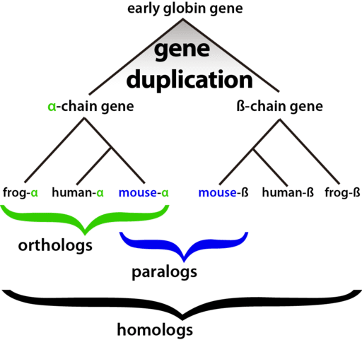

Ver https://bitesizebio.com/26762/homology-terminology-never-say-wrong-word/.

Se han calculado los ortólogos para varios organismos usando el programa BLAST (alineamientos locales, es decir no se obliga a alinear toda la secuencia, pero si las secuencias son parecidas el alineamiento puede cubrir toda la secuencia) (PMID:18042555, 25013894). La detección de ortólogos se usa usando Bidireccional Best Hits. La idea del método de ‘best bidireccional hits (BBHs)’ o mayores parecidos en las dos direcciones es que si una proteína de un genoma es la más parecida de otra en otro genoma, y viceversa (bidireccional), entonces es muy probable que ambas sean ortólogas.

**Salida del programa BLAST**

La salida del BLAST tiene varias secciones, la información general de los parámetros usados para realizar la comparación, b) una sección gráfica donde cada línea es un resultado, y el color indica el score de similitud entre las secuencias, c) La información de los genes con los que se hizo el match mostrando algunos datos de los resultado del blast, c) se muestra los alineamientos, uno por uno, donde se ve la secuencia que se introdujo (query) y las identidades marcadas con “|”, los missmatches, los gap, mostrando la región de la secuencia que alineo juntos con su score.

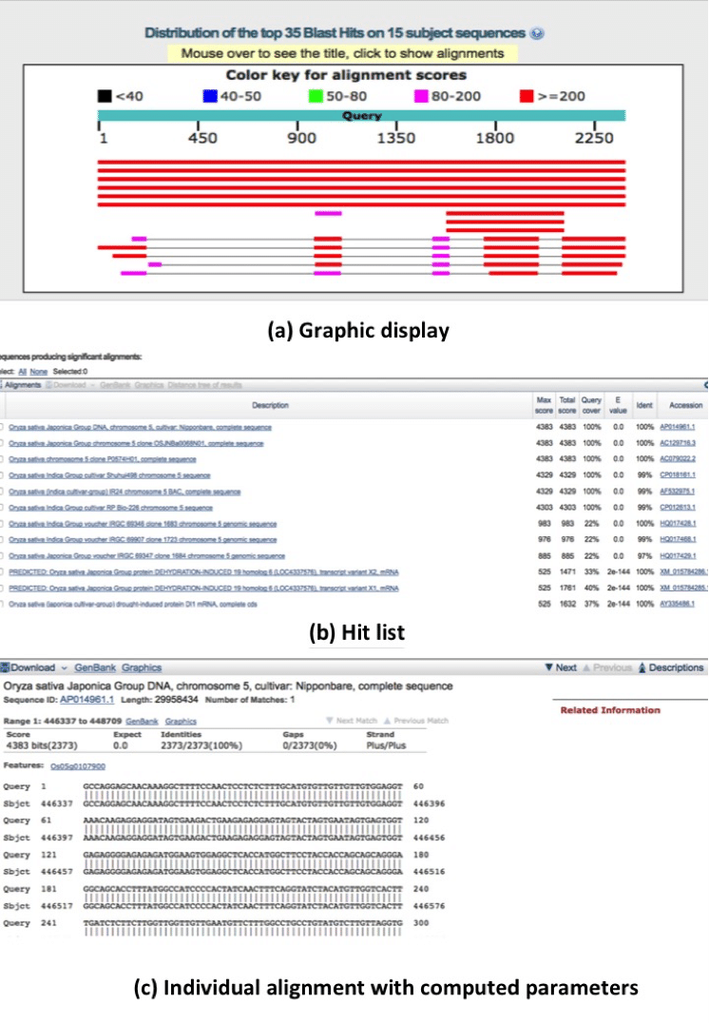

Blast

Una vez que se ejecutan todos las comparaciones entre los genes, y se obtienen todos los resultados del BLAST, se extrae toda la información y se han generado tablas de resultados de la comparación. Se genera un archivo por cada comparación entre genomas y sus genes. El nombre del archivo indica entre qué organismos se hace la comparación, por ejemplo `E_coli_K12.S_typhi.bdbh` indica que se usa E_coli como organismo Query, es decir que se toman los genes de Ecoli para buscarlos en Salmonella thyphi como organismo Target.

Si revisamos cada archivo, cada línea es un gene del genoma al que se le ha encontrado su ortólogo bidireccional en el otro genoma con el que se compara. El archivo resultado de extraer toda la información del resultado del blast, es el siguiente:

```
#1)QueryID      2)TargetID      3)-     4)-     5)-     6)Evalue        7)%queryInAlignment     8)%targetInAlignment    9)Query identities/alignment length     10)Target identities/alignment length   11)Query alignment init,alignment end   12)Target alignment init,alignment end  13)QueryLength  14)T…
16127996        16758995        1       1538    3981    0.0     100     100     774/820 797/820 1,820   1,820   820     820     BI-DIRECTIONAL
16127997        16758996        1       597     1540    1e-169  99      100     288/308 297/308 1,308   1,308   310     309     BI-DIRECTIONAL
16127998        16758997        1       790     2039    0.0     100     100     399/428 411/428 1,428   1,428   428     428     BI-DIRECTIONAL
```

Donde las columnas, no se describen todas, solo las indispensables que utilizarás en el análisis.

- 1. QueryID : GI del organismo query (es el primer nombre del organismo en el nombre del archivo).
- 2. TargetID : GI del organismo target.
- 3. - :
- 4. - :
- 5. - :
- 6. Evalue: The BLAST E-value is the number of expected hits of similar quality (score) that could be found just by chance.
- 7. %queryInAlignment : Indica que porcentaje de la secuencia query se cubrio por el alineamiento.
- 8. %targetInAlignment: Indica que pocentaje de la secuencia Target se cubrio por el alineamiento.
- 9. Query identities/alignment length
- 10. Target identities/alignment length
- 11. Query alignment init,alignment end
- 12. Target alignment init,alignment end
- 13. QueryLength : Tamaño de la secuencia del gene en el organismo Query
- 14. TargetLength : Tamaño de la secuencia del gene en el organismo Target
- 15)Specify Identical

C. **Red de regulación de *E. coli***

El archivo de red de regulación de E. coli https://regulondb.ccg.unam.mx/menu/download/datasets/files/network_tf_gene.txt

Lista de Factores transcripcionales de E. coli

https://regulondb.ccg.unam.mx/menu/download/datasets/files/TFSet.txt

```
# (1) Transcription Factor (TF) identifier assigned by RegulonDB
# (2) TF Name
# (3) TF Synonyms List
# (4) Gene Coding for the TF
# (5) TF Active Conformations
# (6) TF Inactive Conformations

mostrando las columnas de interes..

(1)             (2)     (4)
ECK125328145    AaeR    aaeR
ECK125286586    AccB    accB
ECK120015994    AcrR    acrR
ECK120012595    Ada     ada
ECK120014170    AdiY    adiY
ECK120012515    AgaR    agaR
ECK125134683    AidB    aidB
ECK120030264    AlaS    alaS
ECK120015630    AllR    allR
ECK120015636    AllS    allS
ECK120012984    AlpA    alpA
ECK120011959    AlsR    alsR
```

## Metodología (80%)

Para éste análisis de evaluar la plasticidad de la red de regulación, sólo tomaremos como ejemplo 2 organismos S_typhi y S_typhimurium, para fines didácticos.

Recuerda que en cada pregunta, aunque la respuesta pueda ser un si o no, debes demostrar como llegaste a esa conclusión, asi que debes indicar el código o instrucción que te llevo a esa respuesta.

1. **Revisión de los archivos de entrada**

Por cada organismo indica lo siguiente (puedes crear una tabla con los resultados)

Archivos *.list

1. Total de genes de cada organismo que vienen en el archivo *.list
2. ¿Todos los genes traen nombre?
3. ¿ Todos los genes traen GI y no se repite ?
4. ¿Vienen lineas en blanco o vienen comentarios en el archivo ?

Archivos *.bdbh

5. ¿Cuantos ortologos bidireccionales trae cada archivo.?
6. ¿Vienen lineas en blanco o vienen comentarios en el archivo ?
7. Si crees que es necesario checar algo más de los archivos puedes hacerlo. [extra 0.5 pto]
2. **Sobre los resultados del Blast.**
1. Por cada archivo *.bdbh que contiene los ortologos bidireccionales, extrae cuantos genes de E. coli tienen el mismo tamaño al del organismo target (columna 13,14)
2. ¿Cuántos genes de E. coli además de tener el mismo tamaño, el alineamiento cubrió el 100% tanto de E. coli como del organismo Target ? (columna 7,8 y 13,14)
3. **Sobre la red de regulación**
1. Escoge un TF de la red de regulación, y usando el nombre del gene de TF obten su GI del archivo .list, y verifica que ese TF se encuentre en los archivos *.bdbh. En general, el nombre del TF CRP, su gene es crp, o AraC seria araC. Hay algunas excepciones como IHF que es un regulador heterodimero o complejo donde los genes que lo codifican es ihfA y ihfB. Selecciona un TF donde sea fácil identificar su gene codificador.
2. Usando el TF seleccionado en el punto anterior, obten sus genes regulados, e indica cuántos se conservan en los otros organismos.
3. Usar el archivo de TFSet.txt, obten el gene que lo codifica (columna4) y busca el nombre del gene en el archivo E_coli_K12.list, solo quedate con los reguladores cuyo gene que lo codifica es solo 1. Con esa lista de genes reguladores, busca si existe un ortólogo en los otros organismos. [extra 1 punto]
4. Para cada regulador de la red, obten sus genes regulados y verifica cuantos de ellos tienen un ortólogo y saca el porcentaje de conservación. (El GI te servirá para buscarlos.) [extra 1 punto]

## RESULTADOS Y CONCLUSIONES [ 20% ]

1. Agrega la estructura del proyecto en el reporte.
2. El archivo README que contiene todos lo que hiciste, debe estar también en el servidor dentro de la carpeta del proyecto.
3. Interpretar los resultados según los resultados obtenidos. ¿Qué puedes decir de la red de E. coli y su plasticidad? [ 10% ]
4. Conclusiones de lo aprendido. Puedes ayudarte de las siguientes preguntas ¿Que aprendiste durante la realización de la práctica? ¿qué piensas de unix y sus comandos avanzados? [10%]

## BIBLIOGRAFÍA

Sólo en caso de haber utilizado alguna otra fuente.

1. Bacterial regulatory networks are extremely flexible in evolution https://academic.oup.com/nar/article/34/12/3434/2375626